# Course 4: Project: Excerise Machine Learning

Paul Vinod

06/02/2021

#### **INTRODUCTION**

This is coursera Pratical machine learning project. Here, we would focus on various different factors for weighing different excersies. The goal will be to use data from accelerometers on the belt, forearm, arm, and dumbell of 6 participants. We are provided with both training and testing data.

#### **PROJECT INITIALIZATION**

The project required header files has to be added.

```r
library(ggplot2)
library(GGally)
library(caret)
library(rpart)
library(rattle)
library(randomForest)
library(dplyr)
library(gbm)
```

```r
train_input <-read.csv("https://d396qusza40orc.cloudfront.net/predmachlearn/pml-training.csv",
                    header = TRUE)
test_input <-read.csv("https://d396qusza40orc.cloudfront.net/predmachlearn/pml-testing.csv",
                   header = TRUE)
dim(train_input)
```

```
## [1] 19622   160
```

```r
dim(test_input)
```

```
## [1]  20 160
```

#### **CLEANSING DATA**

Here we need to tidy the data captured and remove missing columns which are completely filled with missing values.

```r
train_data <- train_input[, colSums(is.na(train_input)) == 0] # to remove col with NAs
test_data <- test_input[, colSums(is.na(test_input)) == 0]
dim(train_data)
```

```
## [1] 19622    93
```

```r
dim(test_data)
```

```
## [1] 20 60
```

```r
train_set <- train_data[,-c(1:7)]
valid_set <- test_data[,-c(1:7)]
```

#### **PREDICTION ANALYSIS**

For prediction we need to split the train_data into training set and testing data. For that we would use the R package caret to create partition.

```r
set.seed(1590)
intrain <- createDataPartition(y = train_set$classe,
                               p = 0.8,
                               list = FALSE)
trainData <- train_set[intrain,]
testData <- train_set[-intrain,]
dim(trainData)
```

```
## [1] 15699    86
```

```r
dim(testData)
```

```
## [1] 3923   86
```

```r
# To remove variables which are non-necessary
cols <- nearZeroVar(x = trainData)
trainData <- trainData[,-cols]
testData <- testData[,-cols]
```

##### **Method 1: Random Forest**

Here we would apply **Random Forest** method to create the prediction.

```r
rf_mdl <- train(classe ~ .,
                       data = trainData,
                       method = "rf")
rf_mdl$finalModel
```

```
##
## Call:
##  randomForest(x = x, y = y, mtry = param$mtry)
##                Type of random forest: classification
##                      Number of trees: 500
## No. of variables tried at each split: 27
##
##         OOB estimate of  error rate: 0.59%
## Confusion matrix:
##      A    B    C    D    E  class.error
## A 4462    2    0    0    0 0.0004480287
## B   18 3009   10    1    0 0.0095457538
## C    0   14 2715    9    0 0.0084002922
## D    0    2   22 2546    3 0.0104935873
## E    0    2    2    7 2875 0.0038115038
```

To further check the status of the model.

```r
rf_pred <- predict(object = rf_mdl, newdata = testData)
rf_cm <- confusionMatrix(rf_pred, as.factor(testData$classe))
rf_cm
```

```
## Confusion Matrix and Statistics
##
##           Reference
## Prediction    A    B    C    D    E
##          A 1111    7    0    0    0
##          B    1  752    1    1    0
##          C    3    0  680    5    4
##          D    0    0    3  637    4
##          E    1    0    0    0  713
##
## Overall Statistics
##
##                Accuracy : 0.9924
##                  95% CI : (0.9891, 0.9948)
##     No Information Rate : 0.2845
##     P-Value [Acc > NIR] : < 2.2e-16
##
##                   Kappa : 0.9903
##
##  Mcnemar's Test P-Value : NA
##
## Statistics by Class:
##
##                      Class: A Class: B Class: C Class: D Class: E
## Sensitivity            0.9955   0.9908   0.9942   0.9907   0.9889
## Specificity            0.9975   0.9991   0.9963   0.9979   0.9997
## Pos Pred Value         0.9937   0.9960   0.9827   0.9891   0.9986
## Neg Pred Value         0.9982   0.9978   0.9988   0.9982   0.9975
## Prevalence             0.2845   0.1935   0.1744   0.1639   0.1838
## Detection Rate         0.2832   0.1917   0.1733   0.1624   0.1817
## Detection Prevalence   0.2850   0.1925   0.1764   0.1642   0.1820
## Balanced Accuracy      0.9965   0.9949   0.9952   0.9943   0.9943
```

##### **Method 2: GBM**

Here we would apply **GBM** method to create the prediction.

```r
set.seed(1111)
gbm_trctrl <- trainControl(method = "repeatedcv",
                           repeats = 1,
                           number = 3)
gbm_mdl <- train(classe ~ .,
                       data = trainData,
                       method = "gbm",
                       trControl = gbm_trctrl)
gbm_mdl$finalModel
```

[output not shown]

To further check the status of the model.

```r
gbm_pred <- predict(object = gbm_mdl, newdata = testData)
gbm_cm <- confusionMatrix(gbm_pred, as.factor(testData$classe))
gbm_cm
```

```
## Confusion Matrix and Statistics
##
##           Reference
## Prediction    A    B    C    D    E
##          A 1091   28    0    0    2
##          B   12  704   26    3    6
##          C   12   25  644   22    6
##          D    1    2   12  613    9
##          E    0    0    2    5  698
##
## Overall Statistics
##
##                Accuracy : 0.9559
##                  95% CI : (0.949, 0.9621)
##     No Information Rate : 0.2845
##     P-Value [Acc > NIR] : < 2.2e-16
##
##                   Kappa : 0.9442
##
##  Mcnemar's Test P-Value : 0.0002073
##
## Statistics by Class:
##
##                      Class: A Class: B Class: C Class: D Class: E
## Sensitivity            0.9776   0.9275   0.9415   0.9533   0.9681
## Specificity            0.9893   0.9851   0.9799   0.9927   0.9978
## Pos Pred Value         0.9732   0.9374   0.9083   0.9623   0.9901
## Neg Pred Value         0.9911   0.9827   0.9876   0.9909   0.9929
## Prevalence             0.2845   0.1935   0.1744   0.1639   0.1838
## Detection Rate         0.2781   0.1795   0.1642   0.1563   0.1779
## Detection Prevalence   0.2858   0.1914   0.1807   0.1624   0.1797
## Balanced Accuracy      0.9835   0.9563   0.9607   0.9730   0.9830
```

##### **Method 3: Decision Tree**

Here we would apply **Decision Tree** method to create the prediction.

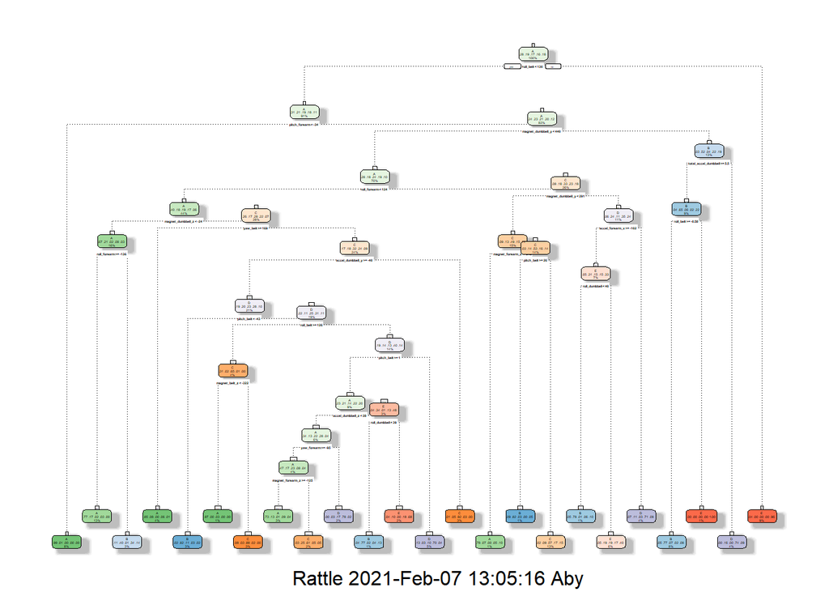

```r
set.seed(3333)
dt_mdl <- rpart(classe ~., data = trainData, method = "class")
fancyRpartPlot(dt_mdl)
```

To further the model performance

```r
dt_pred <- predict(dt_mdl, newdata = testData, type = "class")
dt_cm <- confusionMatrix(dt_pred, as.factor(testData$classe))
dt_cm
```

```
## Confusion Matrix and Statistics
##
##           Reference
## Prediction   A   B   C   D   E
##          A 969 129  15  46  11
##          B  35 435  36  50  61
##          C  39  82 538  93  75
##          D  31  48  46 395  32
##          E  42  65  49  59 542
##
## Overall Statistics
##
##                Accuracy : 0.7339
##                  95% CI : (0.7197, 0.7477)
##     No Information Rate : 0.2845
##     P-Value [Acc > NIR] : < 2.2e-16
##
##                   Kappa : 0.6629
##
##  Mcnemar's Test P-Value : < 2.2e-16
##
## Statistics by Class:
##
##                      Class: A Class: B Class: C Class: D Class: E
## Sensitivity            0.8683   0.5731   0.7865   0.6143   0.7517
## Specificity            0.9284   0.9425   0.9108   0.9521   0.9329
## Pos Pred Value         0.8282   0.7050   0.6505   0.7156   0.7160
## Neg Pred Value         0.9466   0.9020   0.9528   0.9264   0.9435
## Prevalence             0.2845   0.1935   0.1744   0.1639   0.1838
## Detection Rate         0.2470   0.1109   0.1371   0.1007   0.1382
## Detection Prevalence   0.2982   0.1573   0.2108   0.1407   0.1930
## Balanced Accuracy      0.8983   0.7578   0.8487   0.7832   0.8423
```

The overall performance of each prediction model can be depicted as follows:

```r
acc_cm <- data.frame(rf_cm$overall[1], gbm_cm$overall[1], dt_cm$overall[1])
```

#### **RUNNING WITH TEST DATA**

```r
rf_pred_valid <- predict(rf_mdl, newdata = valid_set)

gbm_pred_valid <- predict(gbm_mdl, newdata = valid_set)

dt_pred_valid <- predict(dt_mdl, newdata = valid_set, type = "class")

pred_output <- data.frame(rf_pred_valid,
                          gbm_pred_valid,
                          dt_pred_valid)
headings <- c( "RandomForest", "Gbm", "DecisionTree")
names(pred_output) <- headings
```

#### **CONCLUSION**

```r
acc_cm
```

```
##          rf_cm.overall.1. gbm_cm.overall.1. dt_cm.overall.1.
## Accuracy        0.9923528         0.9559011        0.7338771
```

The predicted output for the validation set is as below:

```r
pred_output
```

```
##    RandomForest Gbm DecisionTree
## 1             B   B            B
## 2             A   A            A
## 3             B   B            E
## 4             A   A            D
## 5             A   A            A
## 6             E   E            C
## 7             D   D            D
## 8             B   B            A
## 9             A   A            A
## 10            A   A            A
## 11            B   B            C
## 12            C   C            E
## 13            B   B            C
## 14            A   A            A
## 15            E   E            E
## 16            E   E            E
## 17            A   A            A
## 18            B   B            B
## 19            B   B            B
## 20            B   B            B
```

Thus, we found the predicted output and most effective was the random forest method having a higher level of accuracy compared to genralized boosting method.